# PEC 1 Análisis de datos ómicos

Jorge Velázquez Gómez

2024-10-31

# Resumen ejecutivo

En este estudio se ha analizado el perfil metabolómico de un conjunto de pacientes para tratar de descubrir dianas prometedoras en la detección del cáncer gástrico. En primer lugar, se han almacenado los datos y metadatos del estudio en un objeto de tipo `SummarizedExperiment` para una organización eficiente de los mismos. A continuación, se han explorado una serie de características de los metabolitos y de las muestras con el fin de obtener información relevante sobre los análisis estadísticos que se pueden llevar a cabo. Después, se ha comprobado si las diferencias en la concentración de una posible diana de interés son estadísticamente significativas a través del test de Kruskal-Wallis. Finalmente, se ha representado un cluster jerárquico para comprobar si las muestras de una misma clase se agrupan de forma natural en función de la distancia entre sus perfiles de expresión de metabolitos, y un Análisis de Componentes Principales (PCA) para comprobar si lo hacen en función de los componentes principales.

# Objetivos del estudio

Los objetivos del estudio han sido:

-Creación de un contenedor del tipo `SummarizedExperiment` que contenga los datos y metadatos del dataset de estudio.

-Exploración de los datos para encontrar variables relevantes de estudio.

-Ejecucion de un proceso simple de análisis ómico con el fin de abordar cuestiones planteadas durante la exploración de los datos.

# Materiales y métodos

Se han utilizado datos pertenecientes a muestras de diferentes pacientes emparejadas mediante espectroscopia de resonancia magnética nuclear de 1H ( 1H - NMR), generando 77 metabolitos reproducibles. Estos datos se encuentran depositados en el **[repositorio de datos de Metabolomics Workbench](http://www.metabolomicsworkbench.org/)** (ID de proyecto PR000699).

Para la gestión y exploración de los datos de expresión, se utilizó el paquete `SummarizedExperiment` de Bioconductor. Para el análisis estadístico se emplearon algunas herramientas de R como la función `hclust()` para realizar un agrupamiento jerárquico de las muestras, la función `aov()` para realizar un test ANOVA o la función `prcomp()` para realizar un Análisis de Componentes Principales.

# Resultados

## Importación de los datos y exploración inicial

En primer lugar, cargamos los datos:

```r
datos<-read_excel("GastricCancer_NMR.xlsx",sheet="Data")
peak<-read_excel("GastricCancer_NMR.xlsx",sheet="Peak")
head(datos)
```

```
## # A tibble: 6 × 153
##     Idx SampleID SampleType Class    M1      M2    M3    M4    M5    M6    M7
##   <dbl> <chr>    <chr>      <chr> <dbl>   <dbl> <dbl> <dbl> <dbl> <dbl> <dbl>
## 1     1 sample_1 QC         QC     90.1   492.  203.   35   164.   19.7  41
## 2     2 sample_2 Sample     GC     43     526.  130.   NA   694.  114.   37.9
## 3     3 sample_3 Sample     BN    214.  10703.  105.   46.8 483.  152.  110.
## 4     4 sample_4 Sample     HE     31.6    59.7  86.4  14    88.6  10.3 170.
## 5     5 sample_5 Sample     GC     81.9   259.  315.    8.7 243.   18.4 349.
## 6     6 sample_6 Sample     BN    197.    128.  862.   18.7 200.    4.7  37.3
## # ℹ 142 more variables: M8 <dbl>, M9 <dbl>, M10 <dbl>, M11 <dbl>, M12 <dbl>,
## #   M13 <dbl>, M14 <dbl>, M15 <dbl>, M16 <dbl>, M17 <dbl>, M18 <dbl>,
## #   M19 <dbl>, M20 <dbl>, M21 <dbl>, M22 <dbl>, M23 <dbl>, M24 <dbl>,
## #   M25 <dbl>, M26 <dbl>, M27 <dbl>, M28 <dbl>, M29 <dbl>, M30 <dbl>,
## #   M31 <dbl>, M32 <dbl>, M33 <dbl>, M34 <dbl>, M35 <dbl>, M36 <dbl>,
## #   M37 <dbl>, M38 <dbl>, M39 <dbl>, M40 <dbl>, M41 <dbl>, M42 <dbl>,
## #   M43 <dbl>, M44 <dbl>, M45 <dbl>, M46 <dbl>, M47 <dbl>, M48 <dbl>, …
```

Observamos que el conjunto de datos presenta 140 filas correspondientes a las diferentes muestras tomadas y 153 columnas correspondientes a las variables de estudio (las 4 primeras contienen información descriptiva sobre las muestras y las 149 restantes las concentraciones de diferentes metabolitos).

```r
str(peak)
```

```
## tibble [149 × 5] (S3: tbl_df/tbl/data.frame)
##  $ Idx         : num [1:149] 1 2 3 4 5 6 7 8 9 10 ...
##  $ Name        : chr [1:149] "M1" "M2" "M3" "M4" ...
##  $ Label       : chr [1:149] "1_3-Dimethylurate" "1_6-Anhydro-β-D-glucose" "1_7-Dimethylxanthine" "1-Methylnicotinamide" ...
##  $ Perc_missing: num [1:149] 11.429 0.714 5 8.571 1.429 ...
##  $ QC_RSD      : num [1:149] 32.21 31.18 34.99 12.8 9.37 ...
```

La tabla peak contiene información sobre los metabolitos como el porcentaje de valores perdidios o el QC_RSD, que es una puntuación de calidad que representa la variación en las mediciones de este metabolito en todas las muestras.

## Limpieza de los datos

Como se indica en el **[flujo de trabajo propuesto por el CIMBC](https://cimcb.github.io/MetabWorkflowTutorial/Tutorial1.html)**, es conveniente evaluar la calidad de los datos y eliminar (limpiar) cualquier metabolito mal medido antes de realizar cualquier análisis estadístico. Para ello vamos a utilizar aquellos metabolitos que cumplan estos dos requisitos:

- Poseer un QC-RSD menor del 20%
- Poseer menos del 10% de valores perdidos

Dicha información se encuentra en la tabla peak, así que impondremos las restricciones en dicha tabla:

```r
peak_filtrado<-peak[peak$QC_RSD < 20 & peak$Perc_missing < 10, ]
nrow(peak_filtrado)
```

```
## [1] 52
```

Observamos que solo 52 metabolitos cumplen ambos requisitos. A continuación, filtraremos en la tabla “Datos” los metabolitos seleccionados y obtendremos la matriz transpuesta, ya que en los objetos de tipo `SummarizedExperiment` las filas representan las características de interés y las columnas representan las muestras:

```r
#Filtramos las columnas y calculamos la transpuesta
datos_limpios<-datos[,peak_filtrado$Name]
datos_limpios_t<-as.data.frame(t(datos_limpios))
#Indicamos como nombre de las columnas los valores de SampleID
colnames(datos_limpios_t)<-datos$SampleID
```

## Creación del contenedor de tipo `SummarizedExperiment`

En la variable `datos_limpios_t` tengo los valores de concentracion de las 140 muestras (columnas) para los 52 metabolitos seleccionados (filas). Vamos a proceder a almacenar los metadatos de las columnas del `SummarizedExperiment` en una variable. Estos metadatos se encuentan en las columnas SampleID, SampleType y Class del dataset original.

```r
colData <- data.frame(SampleID = datos$SampleID, SampleType = datos$SampleType, Class = datos$Class)
rownames(colData)<-datos$SampleID
```

Ahora crearemos una variable para los metadatos de las filas, que contendrá la información almacenada en la tabla “Peak_filtrados”:

```r
rowData <- data.frame(Name = peak_filtrado$Name, Label = peak_filtrado$Label,
          Perc_missing = peak_filtrado$Perc_missing, QC_RSD = peak_filtrado$QC_RSD)
rownames(rowData) <- peak_filtrado$Name
```

Finalmente, procedemos a crear el objeto `SummarizedExperiment`:

```r
se<-`SummarizedExperiment`(assays = list(counts = datos_limpios_t),
                           rowData = rowData, colData = colData)
```

## Exploración del dataset

En primer lugar, podemos visualizar la matriz de datos y los metadatos del objeto `SummarizedExperiment`:

```r
#Matriz de datos (assay)
head(assay(se)[1:10])
```

```
##     sample_1 sample_2 sample_3 sample_4 sample_5 sample_6 sample_7 sample_8
## M4      35.0       NA     46.8     14.0      8.7     18.7       NA     18.2
## M5     164.2    694.5    483.4     88.6    243.2    200.1    362.7     72.5
## M7      41.0     37.9    110.1    170.3    349.4     37.3     59.6     15.3
## M8      46.5    125.7     85.1     23.9     61.1    243.7     51.3     37.1
## M11     61.7    490.6   2441.2    140.7     48.7    103.7     58.1     54.1
## M14     35.3       NA     29.3     62.9     77.8     52.3     34.6     30.3
##     sample_9 sample_10
## M4       8.4      36.0
## M5     270.2     203.4
## M7     213.8      44.4
## M8      65.6      48.6
## M11     92.9      59.0
## M14     61.9      28.4
```

```r
#Metadatos de los metabolitos (filas)
head(rowData(se))
```

```
## DataFrame with 6 rows and 4 columns
##            Name                Label Perc_missing    QC_RSD
##     <character>          <character>    <numeric> <numeric>
## M4           M4 1-Methylnicotinamide      8.57143  12.80420
## M5           M5       2-Aminoadipate      1.42857   9.37266
## M7           M7      2-Furoylglycine      2.85714   5.04916
## M8           M8 2-Hydroxyisobutyrate      0.00000   5.13234
## M11         M11   3-Aminoisobutyrate      5.00000  15.47616
## M14         M14 3-Hydroxyisobutyrate      2.14286   8.90571
```

```r
#Metadatos de las muestras (columnas)
head(colData(se))
```

```
## DataFrame with 6 rows and 3 columns
##             SampleID  SampleType       Class
##          <character> <character> <character>
## sample_1    sample_1          QC          QC
## sample_2    sample_2      Sample          GC
## sample_3    sample_3      Sample          BN
## sample_4    sample_4      Sample          HE
## sample_5    sample_5      Sample          GC
## sample_6    sample_6      Sample          BN
```

Podemos comprobar las dimensiones del objeto `SummarizedExperiment` para confirmar el número de muestras y metabolitos:

```r
dim(se)
```

```
## [1]  52 140
```

Las dimensiones se corresponden con el número de muestras y metabolitos que habíamos filtrado en los pasos previos del análisis. A continuación, elaboraremos un resumen de los metadatos de las fila para conocer cierta información sobre los metabolitos:

```r
summary(as.data.frame(rowData(se)))
```

```
##      Name              Label            Perc_missing        QC_RSD
##  Length:52          Length:52          Min.   :0.0000   Min.   : 2.432
##  Class :character   Class :character   1st Qu.:0.0000   1st Qu.: 5.582
##  Mode  :character   Mode  :character   Median :0.7143   Median : 9.436
##                                        Mean   :1.7720   Mean   :10.145
##                                        3rd Qu.:2.8571   3rd Qu.:14.490
##                                        Max.   :9.2857   Max.   :19.146
```

En este resumen sobre los metadatos de los metabolitos observamos cierta información relevante como que la mediana de Perc_missing es 0.7143%, lo cual sugiere que más del 50% de los metabolitos tienen menos del 1% de valores faltantes o que la media de QC_RSD es 10.145, lo que implica que, en promedio, los metabolitos tienen un RSD en torno al 10%, que es razonable para datos experimentales.

Sería interesante calcular la frecuencia de cada tipo de muestra y cada tipo de clase. Para ello se puede usar la funcion table() en los metadatos de las columnas:

```r
table(colData(se)$SampleType)
```

```
##
##     QC Sample
##     17    123
```

Hay 17 muestras correspondientes a control de calidad y 123 muestras de estudio.

```r
table(colData(se)$Class)
```

```
##
## BN GC HE QC
## 40 43 40 17
```

Hay 40 muestras etiquetadas como tumor benigno, 43 como cáncer gástrico, 40 como control sano y 17 como control de calidad.

Podemos obtener un resumen sobre la distribución de la concentración de metabolitos en una misma muestra usando la función `summary()` en la matriz de datos:

```r
summary(as.data.frame(assays(se)$count[1:10]))
```

```
##     sample_1          sample_2          sample_3          sample_4
##  Min.   :   9.90   Min.   :   16.1   Min.   :    0.2   Min.   :   4.80
##  1st Qu.:  32.42   1st Qu.:  121.7   1st Qu.:   45.6   1st Qu.:  26.25
##  Median :  86.75   Median :  272.8   Median :  136.2   Median :  60.50
##  Mean   : 449.24   Mean   : 1142.9   Mean   :  598.2   Mean   : 225.42
##  3rd Qu.: 226.32   3rd Qu.:  679.7   3rd Qu.:  461.6   3rd Qu.: 138.45
##  Max.   :8029.50   Max.   :16744.8   Max.   :12939.2   Max.   :4562.60
##                    NA's   :2         NA's   :2         NA's   :1
##     sample_5          sample_6          sample_7           sample_8
##  Min.   :    3.9   Min.   :   1.60   Min.   :    9.60   Min.   :   3.70
##  1st Qu.:   48.8   1st Qu.:  38.45   1st Qu.:   49.88   1st Qu.:  15.07
##  Median :  197.8   Median : 124.60   Median :  149.85   Median :  37.10
##  Mean   :  554.7   Mean   : 489.20   Mean   :  638.62   Mean   : 179.95
##  3rd Qu.:  415.4   3rd Qu.: 242.60   3rd Qu.:  353.65   3rd Qu.:  81.78
##  Max.   :12562.3   Max.   :8484.20   Max.   :13681.80   Max.   :2665.00
##  NA's   :1         NA's   :1         NA's   :2
##     sample_9         sample_10
##  Min.   :   0.20   Min.   :  12.60
##  1st Qu.:  39.38   1st Qu.:  34.92
##  Median :  76.20   Median :  99.55
##  Mean   : 448.43   Mean   : 436.12
##  3rd Qu.: 351.23   3rd Qu.: 236.97
##  Max.   :6864.30   Max.   :7915.50
##
```

También podemos obtener un resumen de cada metabolito:

```r
summary(t(assays(se)$count[1:10, ]))
```

```
##        M4               M5               M7               M8
##  Min.   :  0.10   Min.   :   1.3   Min.   :  4.60   Min.   :  9.30
##  1st Qu.: 18.77   1st Qu.:  67.0   1st Qu.: 19.65   1st Qu.: 37.17
##  Median : 35.70   Median : 160.3   Median : 40.25   Median : 51.00
##  Mean   : 43.83   Mean   : 231.1   Mean   : 74.12   Mean   : 67.81
##  3rd Qu.: 51.33   3rd Qu.: 253.1   3rd Qu.: 65.55   3rd Qu.: 77.83
##  Max.   :242.50   Max.   :2503.0   Max.   :492.60   Max.   :525.00
##  NA's   :12       NA's   :2        NA's   :4
##       M11              M14              M15              M25
##  Min.   :   0.3   Min.   :  0.20   Min.   :  7.90   Min.   :  0.40
##  1st Qu.:  47.0   1st Qu.: 30.40   1st Qu.: 28.80   1st Qu.: 12.20
##  Median :  82.9   Median : 50.40   Median : 44.10   Median : 18.25
##  Mean   : 192.5   Mean   : 68.75   Mean   : 57.16   Mean   : 24.23
##  3rd Qu.: 164.7   3rd Qu.: 83.70   3rd Qu.: 71.08   3rd Qu.: 28.50
##  Max.   :2676.3   Max.   :437.60   Max.   :212.30   Max.   :171.80
##  NA's   :7        NA's   :3
##       M26              M31
##  Min.   :  2.00   Min.   :   0.20
##  1st Qu.: 13.80   1st Qu.:  13.60
##  Median : 20.90   Median :  24.10
##  Mean   : 28.31   Mean   :  70.59
##  3rd Qu.: 30.80   3rd Qu.:  61.55
##  Max.   :374.60   Max.   :1336.60
##  NA's   :8        NA's   :1
```

Con algo más de trabajo, podemos obtener cierta información relevante como cuales son los metabolitos que presentan mayor concentración para cada clase. Los resultados se encuentran expuestos en la siguiente tabla:

Tabla de metabolitmos con mayor concentración media en cada clase

|  | 1 | 2 | 3 | 4 | 5 | 6 |
| --- | --- | --- | --- | --- | --- | --- |
| GC | M48: 8838.94 | M45: 2386.34 | M66: 2114.04 | M134: 1993.97 | M129: 1921.22 | M138: 1521 |
| BN | M48: 10394.27 | M45: 2803.79 | M129: 1578.97 | M134: 1251 | M66: 1242.15 | M137: 1203.01 |
| HE | M48: 11747.39 | M45: 4629.9 | M129: 1720.52 | M66: 1271.77 | M137: 1133.86 | M134: 687.17 |
| QC | M48: 7809.06 | M66: 3114.12 | M137: 2742.74 | M129: 2412.21 | M134: 696.31 | M148: 654.97 |

Observamos que para todas las clases el metabolito que mayor concentración presenta es M48, seguido de M45 para todos los casos menos para el control de calidad.

También podemos investigar cuales son los metabolitos que mayor diferencia de expresión presentan entre las muestras etiquetadas como cáncer gástrico y las muestras etiquetadas como tumor benigno y control sano, para tratar de encontrar genes implicados en este tipo de tumor. No escalamos los datos debido a que se prefiere analizar las diferencias en las concentraciones en términos absolutos, para una mejor interpretación biológica.

Tabla de metabolitmos con mayor diferencia de concentración media entre las clases

|  | 1 | 2 | 3 | 4 | 5 | 6 |
| --- | --- | --- | --- | --- | --- | --- |
| Entre GC y BN | M48: 1555.33 | M66: 871.89 | M134: 742.98 | M45: 417.45 | M138: 354.06 | M129: 342.25 |
| Entre GC y HE | M48: 2908.45 | M45: 2243.56 | M134: 1306.81 | M138: 1188.07 | M66: 842.27 | M89: 587.92 |
| Entre BN y HE | M45: 1826.12 | M48: 1353.12 | M138: 834.01 | M134: 563.83 | M89: 526.9 | M50: 428.91 |

El metabolito que presenta mayor diferencia en concentración media entre muestras etiquetadas como cáncer gástrico y tumor benigno, y cancer gástrico y control sano , es M48 en ambos casos, por lo que la concentración de este metabolito podría estar implicada en el desarrollo de este tipo de tumor.

Podemos representar un `Boxplot` para comparar de forma más visual la distribución del metabolito M48 en las diferentes clases.

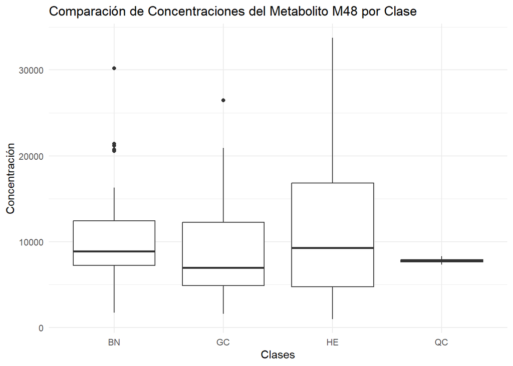

Como se esperaba la clase QC presenta la menor dispersión, ya que estas muestras actúan como control de calidad manteniendo concentraciones consistentes. Podemos ver que la concentración de M48 en la clase GC es más baja en comparación con BN y esta a su vez más baja respecto a HE, lo que sugiere que la disminución en la concentración de este metabolito podría estar asociado con el cáncer, siendo esa primera disminución en las muestras BN una respuesta temprana o una alteración metabólica que podría ocurrir en etapas previas a la malignización completa.

## Análisis estadísticos

Para comprobar si las diferencias observadas en la concentraciones de este metabolito entre las clases son estadísticamente significativas podemos realizar un ANOVA, o en su defecto, si no hay normalidad y homogeneidad de varianza en los datos de una misma clase, un test no paramétrico como el Test de Kruskal-Wallis.

```r
shapiro.test(datos_limpios_class$M48[datos_limpios_class$Class == "GC"])
```

```
##
##  Shapiro-Wilk normality test
##
## data:  datos_limpios_class$M48[datos_limpios_class$Class == "GC"]
## W = 0.90924, p-value = 0.002414
```

```r
shapiro.test(datos_limpios_class$M48[datos_limpios_class$Class == "HE"])
```

```
##
##  Shapiro-Wilk normality test
##
## data:  datos_limpios_class$M48[datos_limpios_class$Class == "HE"]
## W = 0.90244, p-value = 0.002253
```

Dado que el p-value obtenido para GC y HE es menor a 0,05 podemos asumir que las concetraciones de los metabolitos en cada grupo no siguen una distribución normal. Optaremos entonces por el Test de Kruskal-Wallis:

```r
kruskal.test(M48 ~ Class, data = datos_limpios_class)
```

```
##
##  Kruskal-Wallis rank sum test
##
## data:  M48 by Class
## Kruskal-Wallis chi-squared = 3.7306, df = 3, p-value = 0.2921
```

El p-valor es mayor a 0,05 por lo que no hay evidencias para rechazar la hipótesis nula y asumimos que no hay diferencias estadísticamente significativas en los niveles del metabolito M48 entre las difentes clases.

Para obtener más información relevante, como cuales son los metabolitos que presentan mayor correlación con el metabolito M48, podemos representar una matriz de correlación entre los metabolitos. En este caso usaremos la librería pheatmap, que nos permiten representar la matriz de una manera intuitiva en forma de mapa de calor:

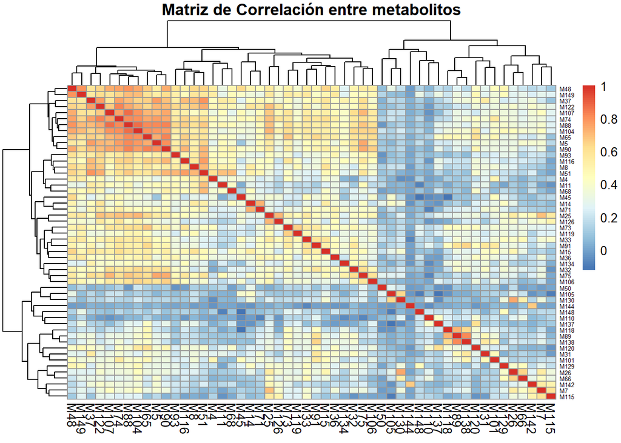

Otro anális que se puede realizar es representar un clúster jerarquico entre las muestras para comprobar si muestras de una misma clase se agrupan de forma natural en función de sus distancias en el perfil de expresión de metabolitos.Antes de construirlo realizaremos un escalado estándar de los datos, para que todas las variables contribuyan de manera equitativa al análisis.

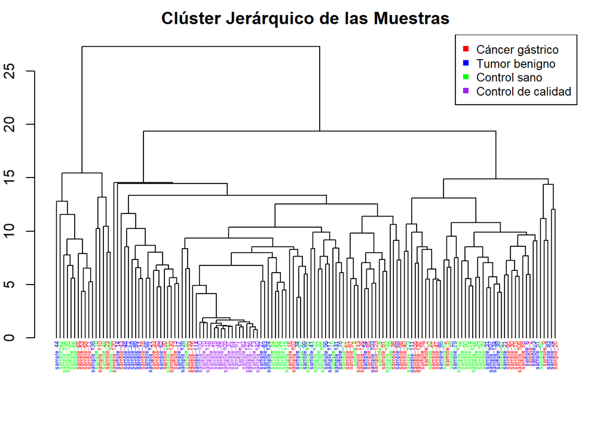

Finalmente, realizaremos un análisis de componentes principales (PCA) para ver como se distribuyen las muestras pertenecientes a las diferentes clases en función de los 2 componentes principales, que son combinaciones lineales de las variables originales que buscan capturar la mayor cantidad de variabilidad posible en los datos. Antes de ello eliminaremos los valores nulos ya que la función `pcrcomp()` no puede manejar dichos valores e indicaremos la opción scale.=TRUE de esta función para hacer un escalado estándar de los datos.

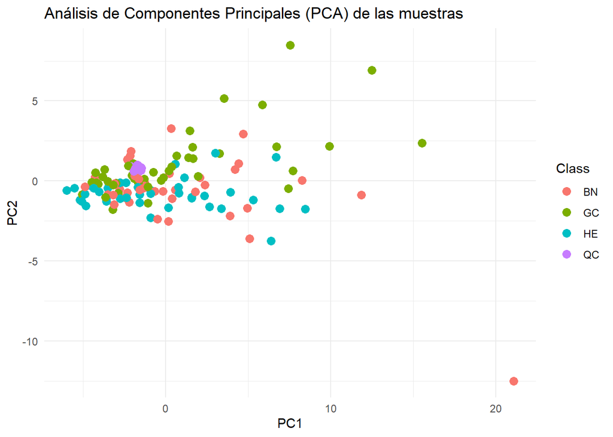

En este gráfico, parece que algunas clases muestran una ligera agrupación (por ejemplo, los puntos verdes GC y azules HE), lo que sugiere que pueden tener patrones distintos. Sin embargo, también hay solapamiento entre las clases, lo que indica que las diferencias no son completamente distinguibles en estas dos dimensiones. En cuanto a los componentres principales, las muestras de cáncer gástrico parece que tienden a tener un mayor valor de PC2 si las comparamos con los controles sanos principalmente.

# Conclusiones del estudio

En las búsqueda de posibles metabolitos implicados en el desarrollo del cáncer gástrico se encontro que el metabolito que mayor diferencia en concentración media presentaba entre muestras con cáncer gástrico y el resto de clases era el denominado M48 . Sin embargo, se realizó un test de Kruskal-Walli para comprobar si las diferencias observadas eran estadísticamente significativas y se obtuvo un p-valor superior a 0.05 por lo que no se pueden asumir dichar diferencias. Una solución para obtener mejores resultados podría ser escalar los datos antes de realizar estos análisis, aunque como ya se mencionó previamente, para este análisis se prefirió trabajar con las concentraciones originales para una mayor veracidad en la interpretación biológica.

En cuanto a los resultados del Clusting Jerárquico y el Análisis de Componentes Principales (PCA),parece que no se consiguió agrupar de forma muy precisa las muestras de forma natural de acuerdo a las clases esperadas. Esto puede deberse a que las variables estudiadas no capturan las diferencias biológicas clave entre las clases o que haya mucha variabilidad dentro de las propias clases, por lo que sería interesante analizar subtipos dentro de las propias clases.